# SwitchinGears_timklaassen

Tim Klaassen

2025-02-14

# Introduction

This is an RMarkdown template. You can write regular text here, including **bold**, *italics*, and `code`.

# Load Data

```r
cars <- mpg  # Example dataset native to R
```

# Summary Statistics

```r
summary(cars)
```

```
##  manufacturer          model               displ            year
##  Length:234         Length:234         Min.   :1.600   Min.   :1999
##  Class :character   Class :character   1st Qu.:2.400   1st Qu.:1999
##  Mode  :character   Mode  :character   Median :3.300   Median :2004
##                                        Mean   :3.472   Mean   :2004
##                                        3rd Qu.:4.600   3rd Qu.:2008
##                                        Max.   :7.000   Max.   :2008
##       cyl           trans               drv                 cty
##  Min.   :4.000   Length:234         Length:234         Min.   : 9.00
##  1st Qu.:4.000   Class :character   Class :character   1st Qu.:14.00
##  Median :6.000   Mode  :character   Mode  :character   Median :17.00
##  Mean   :5.889                                         Mean   :16.86
##  3rd Qu.:8.000                                         3rd Qu.:19.00
##  Max.   :8.000                                         Max.   :35.00
##       hwy             fl               class
##  Min.   :12.00   Length:234         Length:234
##  1st Qu.:18.00   Class :character   Class :character
##  Median :24.00   Mode  :character   Mode  :character
##  Mean   :23.44
##  3rd Qu.:27.00
##  Max.   :44.00
```

Create the Boxplot We will create a boxplot that displays engine size (displ) per car class (class) with the following customizations:

Individual Data Points: Color the points based on the car manufacturer. Change Theme: Use the classic theme. Set Axis Limits: Set the y-axis limits from 0 to 10. Remove Outliers: Exclude outliers from the boxplot. # Create the boxplot with customizations

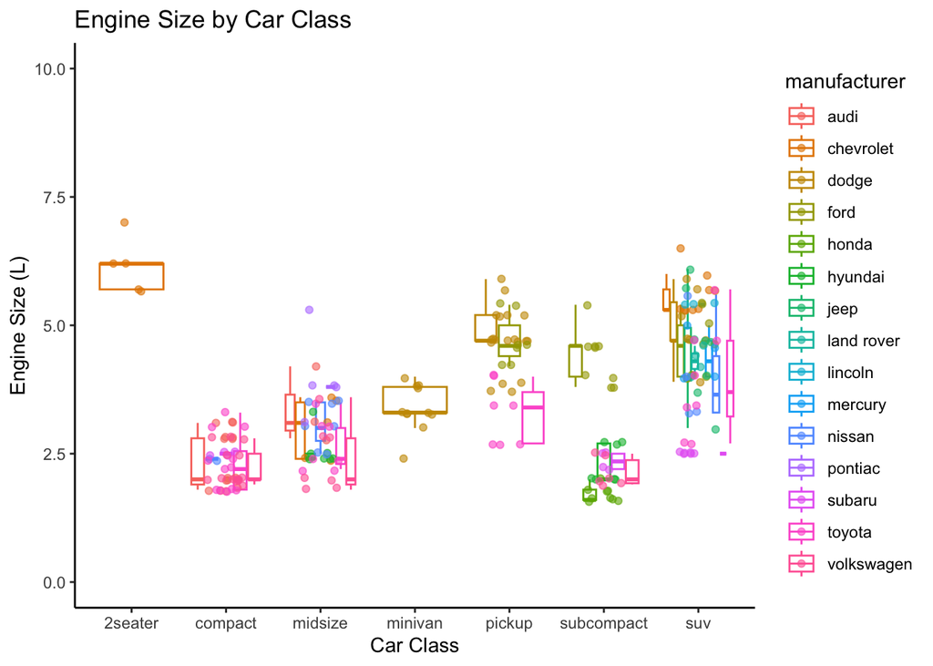

```r
ggplot(cars, aes(x = class, y = displ, color = manufacturer)) +
  geom_boxplot(outlier.shape = NA) +  # Hide outliers
  geom_jitter(alpha = 0.6, width = 0.2) +  # Add data points with jitter
  scale_y_continuous(limits = c(0, 10)) +  # Set y-axis limits from 0 to 10
  theme_classic() +  # Change the theme to "classic"
  labs(
    title = "Engine Size by Car Class",
    x = "Car Class",
    y = "Engine Size (L)"
  )
```

#Explanation ggplot(mpg, aes(x = class, y = displ, color = manufacturer)): Specifies the dataset (mpg) and maps the class to the x-axis, displ (engine size) to the y-axis, and manufacturer to the color aesthetic for the points. geom_boxplot(outlier.shape = NA): Creates a boxplot and hides outliers by setting outlier.shape = NA. geom_jitter(alpha = 0.6, width = 0.2): Adds individual data points to the plot with slight horizontal jitter to avoid overlapping points. The alpha parameter adjusts the transparency, and the width controls the horizontal spread of the points. scale_y_continuous(limits = c(0, 10)): Customizes the y-axis limits to range from 0 to 10. theme_classic(): Applies the classic theme for a clean look. labs(…): Adds informative titles and axis labels for better understanding.

#further illustrations/plots using piping, ggplot2 and functions Below is an script that includes multiple ggplot2 visualizations using the mpg dataset. It also incorporates pipes (%>% from dplyr) and simple functions to manipulate and visualize data effectively.

This script includes:

A scatter plot of engine size vs. highway MPG. A boxplot showing highway MPG per car class. A bar chart of the number of cars per manufacturer. A density plot of highway MPG. It also provides explanations through comments in the code. You can copy and paste it directly into an RMarkdown file and knit it to an HTML or PDF report.

# Scatter plot of engine displacement vs highway MPG

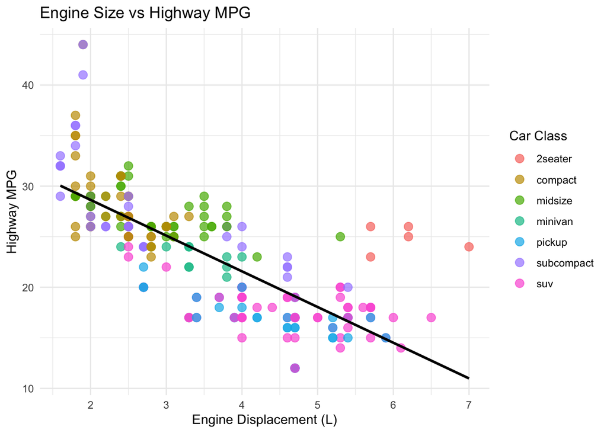

```r
car <- mpg  # Assign dataset to variable "car"
car %>%
  ggplot(aes(x = displ, y = hwy, color = class)) +
  geom_point(alpha = 0.7, size = 3) +  # Scatter points with transparency
  geom_smooth(method = "lm", se = FALSE, color = "black") +  # Add trend line
  labs(
    title = "Engine Size vs Highway MPG",
    x = "Engine Displacement (L)",
    y = "Highway MPG",
    color = "Car Class"
  ) +
  theme_minimal()  # Use a clean theme
```

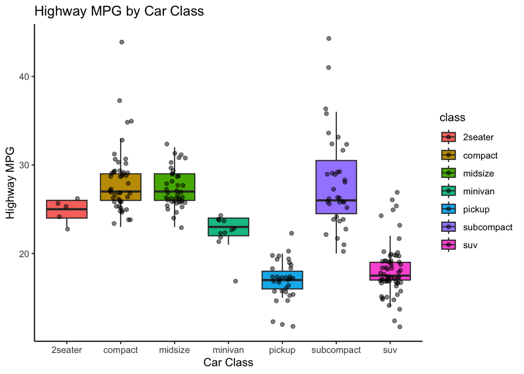

```r
# Boxplot of highway MPG per car class
car %>%
  ggplot(aes(x = class, y = hwy, fill = class)) +
  geom_boxplot(outlier.shape = NA) +  # Remove outliers
  geom_jitter(width = 0.2, alpha = 0.5) +  # Add jittered points
  labs(
    title = "Highway MPG by Car Class",
    x = "Car Class",
    y = "Highway MPG"
  ) +
  theme_classic()  # Use a classic theme
```

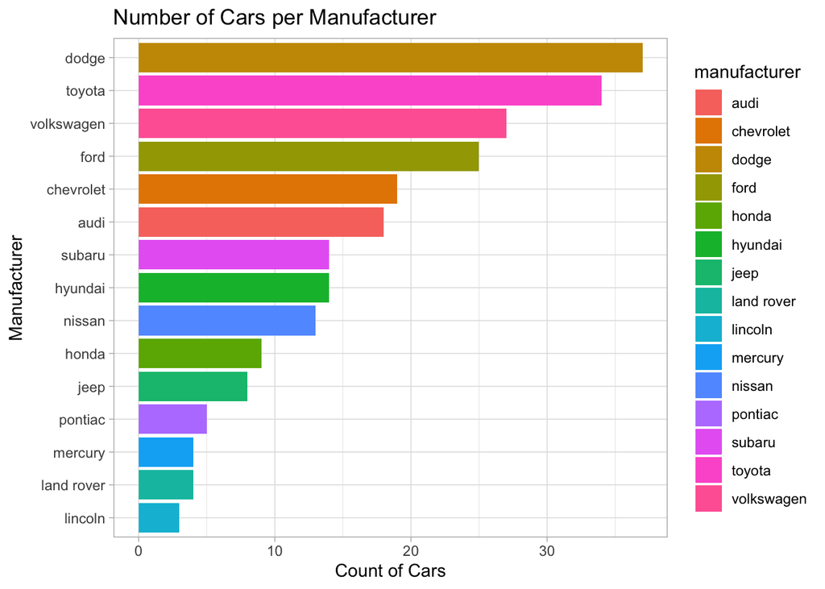

```r
# Count number of cars per manufacturer
car %>%
  count(manufacturer) %>%
  ggplot(aes(x = reorder(manufacturer, n), y = n, fill = manufacturer)) +
  geom_col() +  # Bar chart
  coord_flip() +  # Flip for better readability
  labs(
    title = "Number of Cars per Manufacturer",
    x = "Manufacturer",
    y = "Count of Cars"
  ) +
  theme_light()  # Use a light theme
```

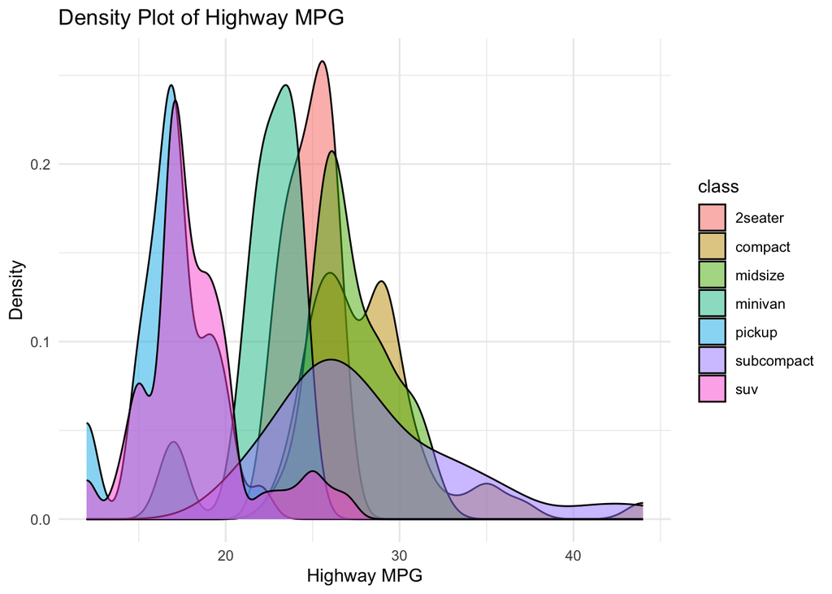

```r
# Density plot of highway MPG
car %>%
  ggplot(aes(x = hwy, fill = class)) +
  geom_density(alpha = 0.5) +  # Add transparency
  labs(
    title = "Density Plot of Highway MPG",
    x = "Highway MPG",
    y = "Density"
  ) +
  theme_minimal()  # Use a minimal theme
```

#Functions are a great way to make your RMarkdown code cleaner, reusable, and modular. Below is an RMarkdown script that defines custom functions to create ggplots using the mpg dataset. This makes the code more organized and reusable.

#1. Function for a Scatter Plot This function creates a scatter plot of displ vs. hwy and allows customization of color.

```r
plot_scatter <- function(data, color_var = "class") {
  data %>%
    ggplot(aes(x = displ, y = hwy, color = .data[[color_var]])) +
    geom_point(alpha = 0.7, size = 3) +  # Transparent points
    geom_smooth(method = "lm", se = FALSE, color = "black") +  # Trend line
    labs(
      title = "Engine Size vs Highway MPG",
      x = "Engine Displacement (L)",
      y = "Highway MPG",
      color = "Car Attribute"
    ) +
    theme_minimal()  # Clean theme
}
```

#Now, let’s use this function:

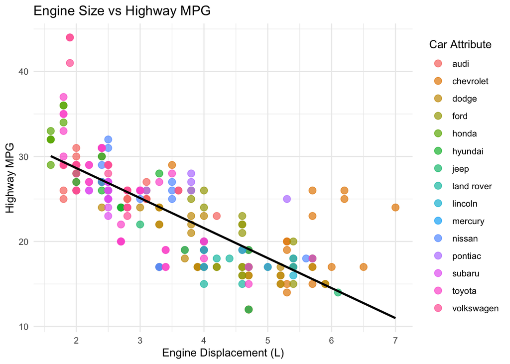

```r
car <- mpg  # Assign dataset to "car"
plot_scatter(car, color_var = "manufacturer")  # Call function with custom color
```